## Bank Customers Churn Prediction

# Description

## Background and Context

Businesses like banks that provide service have to worry about the problem of 'Churn' i.e. customers leaving and joining another service provider. It is important to understand which aspects of the service influence a customer's decision in this regard. Management can concentrate efforts on the improvement of service, keeping in mind these priorities.

## Objective

Given a Bank customer, build a neural network-based classifier that can determine whether they will leave or not in the next 6 months.

## Data Description

The case study is from an open-source dataset from Kaggle. The dataset contains 10,000 sample points with 14 distinct features such as CustomerId, CreditScore, Geography, Gender, Age, Tenure, Balance, etc.

### Data Dictionary

- CustomerId: Unique ID which is assigned to each customer
- Surname: Last name of the customer
- CreditScore: It defines the credit history of the customer.
- Geography: A customer’s location
- Gender: It defines the Gender of the customer
- Age: Age of the customer
- Tenure: Number of years for which the customer has been with the bank
- NumOfProducts: It refers to the number of products that a customer has purchased through the bank.
- Balance: Account balance
- HasCrCard: It is a categorical variable that decides whether the customer has a credit card or not.
- EstimatedSalary: Estimated salary
- isActiveMember: It is a categorical variable that decides whether the customer is an active member of the bank or not ( Active member in the sense, using bank products regularly, making transactions, etc )
- Excited: It is a categorical variable that decides whether the customer left the bank within six months or not. It can take two values
  - 0=No (Customer did not leave the bank)
  - 1=Yes ( Customer left the bank )

# Reading Dataset and Feature Elimination

## Importing Libraries

```python
import pandas as pd
import numpy as np
from sklearn.model_selection import train_test_split
from sklearn.preprocessing import LabelEncoder, OneHotEncoder
from sklearn import model_selection
from sklearn.compose import ColumnTransformer
import matplotlib.pyplot as plt
import seaborn as sns
sns.set()
from sklearn.impute import SimpleImputer
import warnings
from sklearn.metrics import confusion_matrix, classification_report
from sklearn.pipeline import Pipeline
from sklearn.model_selection import GridSearchCV
from sklearn.model_selection import RandomizedSearchCV
import tensorflow as tf
from tensorflow.keras.models import Sequential
from tensorflow.keras.layers import Dense
from tensorflow.keras.layers import Dense, Input, Dropout,BatchNormalization
from tensorflow.keras.wrappers.scikit_learn import KerasClassifier
import random
from tensorflow.keras import backend
random.seed(1)
np.random.seed(1)
tf.random.set_seed(1)
warnings.filterwarnings("ignore")

from sklearn.metrics import accuracy_score,precision_score,recall_score,f1_score

# This will help in making the Python code more structured automatically (good coding practice)
#%load_ext nb_black

# To oversample and undersample data
from imblearn.over_sampling import SMOTE
from imblearn.under_sampling import RandomUnderSampler

from tensorflow import keras
from tensorflow.keras import layers
from kerastuner.tuners import RandomSearch

# Removes the limit for the number of displayed columns
pd.set_option("display.max_columns", None)
# Sets the limit for the number of displayed rows
pd.set_option("display.max_rows", 200)
# Coerce printing of floats in 2 d.p
pd.options.display.float_format = '{:,.3f}'.format
```

## Loading the Data

```python
Data = pd.read_csv('Churn.csv')
```

```python
# Checking the number of rows and columns in the data
Data.shape
```

```
(10000, 14)
```

- The dataset has 10,000 rows and 14 columns

## Loading the Data

```python
# Let's view the first 5 rows of the data
Data.sample(5)
```

|  | RowNumber | CustomerId | Surname | CreditScore | Geography | Gender | Age | Tenure | Balance | NumOfProducts | HasCrCard | IsActiveMember | EstimatedSalary | Exited |
| --- | --- | --- | --- | --- | --- | --- | --- | --- | --- | --- | --- | --- | --- | --- |
| 9953 | 9954 | 15655952 | Burke | 550 | France | Male | 47 | 2 | 0.000 | 2 | 1 | 1 | 97,057.280 | 0 |
| 3850 | 3851 | 15775293 | Stephenson | 680 | France | Male | 34 | 3 | 143,292.950 | 1 | 1 | 0 | 66,526.010 | 0 |
| 4962 | 4963 | 15665088 | Gordon | 531 | France | Female | 42 | 2 | 0.000 | 2 | 0 | 1 | 90,537.470 | 0 |
| 3886 | 3887 | 15720941 | Tien | 710 | Germany | Male | 34 | 8 | 147,833.300 | 2 | 0 | 1 | 1,561.580 | 0 |
| 5437 | 5438 | 15733476 | Gonzalez | 543 | Germany | Male | 30 | 6 | 73,481.050 | 1 | 1 | 1 | 176,692.650 | 0 |

```python
# Let's check the datatypes of the columns in the dataset
Data.info()
```

```
<class 'pandas.core.frame.DataFrame'>
RangeIndex: 10000 entries, 0 to 9999
Data columns (total 14 columns):
 #   Column           Non-Null Count  Dtype
---  ------           --------------  -----
 0   RowNumber        10000 non-null  int64
 1   CustomerId       10000 non-null  int64
 2   Surname          10000 non-null  object
 3   CreditScore      10000 non-null  int64
 4   Geography        10000 non-null  object
 5   Gender           10000 non-null  object
 6   Age              10000 non-null  int64
 7   Tenure           10000 non-null  int64
 8   Balance          10000 non-null  float64
 9   NumOfProducts    10000 non-null  int64
 10  HasCrCard        10000 non-null  int64
 11  IsActiveMember   10000 non-null  int64
 12  EstimatedSalary  10000 non-null  float64
 13  Exited           10000 non-null  int64
dtypes: float64(2), int64(9), object(3)
memory usage: 1.1+ MB
```

- There are 10,000 observations and 14 columns in the data.
- 3 columns are of the object datatype and 11 columns are numerical.

```python
# Let's check for duplicate values in the data
Data.duplicated().sum()
```

```
0
```

```python
# Let's check for missing values in the data
Data.isnull().sum()
```

```
RowNumber          0
CustomerId         0
Surname            0
CreditScore        0
Geography          0
Gender             0
Age                0
Tenure             0
Balance            0
NumOfProducts      0
HasCrCard          0
IsActiveMember     0
EstimatedSalary    0
Exited             0
dtype: int64
```

```python
# Let's view the statistical summary of the numerical columns in the data
Data.describe().T
```

|  | count | mean | std | min | 25% | 50% | 75% | max |
| --- | --- | --- | --- | --- | --- | --- | --- | --- |
| RowNumber | 10,000.000 | 5,000.500 | 2,886.896 | 1.000 | 2,500.750 | 5,000.500 | 7,500.250 | 10,000.000 |
| CustomerId | 10,000.000 | 15,690,940.569 | 71,936.186 | 15,565,701.000 | 15,628,528.250 | 15,690,738.000 | 15,753,233.750 | 15,815,690.000 |
| CreditScore | 10,000.000 | 650.529 | 96.653 | 350.000 | 584.000 | 652.000 | 718.000 | 850.000 |
| Age | 10,000.000 | 38.922 | 10.488 | 18.000 | 32.000 | 37.000 | 44.000 | 92.000 |
| Tenure | 10,000.000 | 5.013 | 2.892 | 0.000 | 3.000 | 5.000 | 7.000 | 10.000 |
| Balance | 10,000.000 | 76,485.889 | 62,397.405 | 0.000 | 0.000 | 97,198.540 | 127,644.240 | 250,898.090 |
| NumOfProducts | 10,000.000 | 1.530 | 0.582 | 1.000 | 1.000 | 1.000 | 2.000 | 4.000 |
| HasCrCard | 10,000.000 | 0.706 | 0.456 | 0.000 | 0.000 | 1.000 | 1.000 | 1.000 |
| IsActiveMember | 10,000.000 | 0.515 | 0.500 | 0.000 | 0.000 | 1.000 | 1.000 | 1.000 |
| EstimatedSalary | 10,000.000 | 100,090.240 | 57,510.493 | 11.580 | 51,002.110 | 100,193.915 | 149,388.247 | 199,992.480 |
| Exited | 10,000.000 | 0.204 | 0.403 | 0.000 | 0.000 | 0.000 | 0.000 | 1.000 |

**Observation**

- Customers are between the Age of 18 - 92.
- No customer has purchased more than 4 products from the bank.
- Customer estimated salary ranged from \$11 to \\$199,992

## Elimination of Unique Fearures

```python
# Let's check the number of unique values in each column
Data.nunique()
```

```
RowNumber          10000
CustomerId         10000
Surname             2932
CreditScore          460
Geography              3
Gender                 2
Age                   70
Tenure                11
Balance             6382
NumOfProducts          4
HasCrCard              2
IsActiveMember         2
EstimatedSalary     9999
Exited                 2
dtype: int64
```

- Each value of the columns 'RowNumber' and 'CustomerId' are unique identifiers for a customer.
- There are 2,932 unique values for the Surname. Also, the surname does not add extra information useful for building a predictive model.
- The redundant columns will be dropped during data pre-processing

```python
# Dropping redundant
Data.drop(columns=["RowNumber", "CustomerId", "Surname"], inplace=True)
```

```python
for i in Data.describe(include=["object"]).columns:
    print("Unique values in", i, "are :")
    print(Data[i].value_counts())
    print("*" * 50)
```

```
Unique values in Geography are :
France     5014
Germany    2509
Spain      2477
Name: Geography, dtype: int64
Unique values in Gender are :
Male      5457
Female    4543
Name: Gender, dtype: int64
```

# Exploratory Data Analysis

## Univariate Analysis

```python
# function to plot a boxplot and a histogram along the same scale.


def histogram_boxplot(data, feature, figsize=(12, 7), kde=False, bins=None):
    """
    Boxplot and histogram combined

    data: dataframe
    feature: dataframe column
    figsize: size of figure (default (12,7))
    kde: whether to the show density curve (default False)
    bins: number of bins for histogram (default None)
    """
    f2, (ax_box2, ax_hist2) = plt.subplots(
        nrows=2,  # Number of rows of the subplot grid= 2
        sharex=True,  # x-axis will be shared among all subplots
        gridspec_kw={"height_ratios": (0.25, 0.75)},
        figsize=figsize,
    )  # creating the 2 subplots
    sns.boxplot(
        data=data, x=feature, ax=ax_box2, showmeans=True, color="violet"
    )  # boxplot will be created and a star will indicate the mean value of the column
    sns.histplot(
        data=data, x=feature, kde=kde, ax=ax_hist2, bins=bins, palette="winter"
    ) if bins else sns.histplot(
        data=data, x=feature, kde=kde, ax=ax_hist2
    )  # For histogram
    ax_hist2.axvline(
        data[feature].mean(), color="green", linestyle="--"
    )  # Add mean to the histogram
    ax_hist2.axvline(
        data[feature].median(), color="black", linestyle="-"
    )  # Add median to the histogram
```

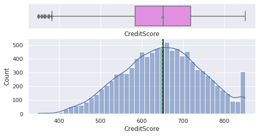

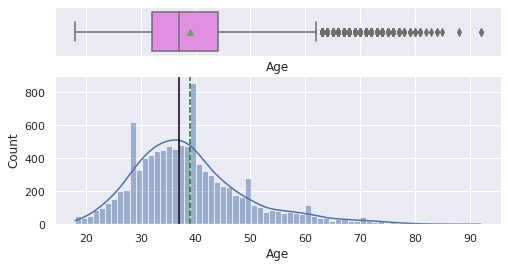

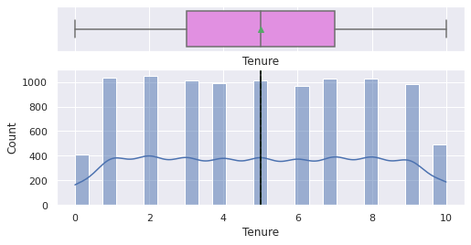

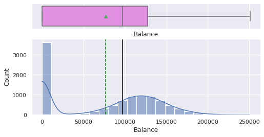

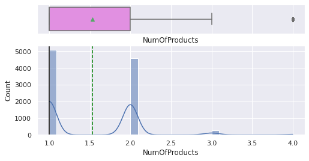

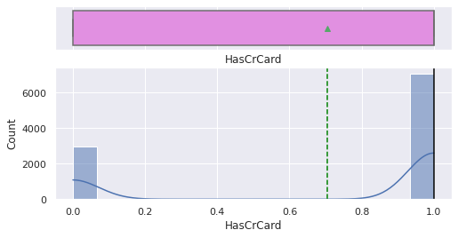

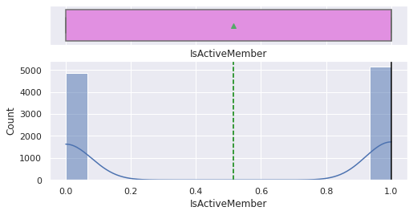

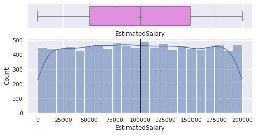

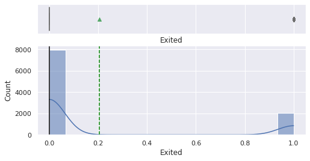

```python
# selecting numerical columns
num_col = Data.select_dtypes(include=np.number).columns.tolist()

for item in num_col:
    histogram_boxplot(Data, item, kde=True, figsize=(8, 4))
```

**Observation**

```python
# Function to create labeled barplots


def labeled_barplot(data, feature, perc=True, n=None):
    """
    Barplot with percentage at the top

    data: dataframe
    feature: dataframe column
    perc: whether to display percentages instead of count (default is False)
    n: displays the top n category levels (default is None, i.e., display all levels)
    """

    total = len(data[feature])  # length of the column
    count = data[feature].nunique()
    if n is None:
        plt.figure(figsize=(count + 1, 5))
    else:
        plt.figure(figsize=(n + 1, 5))

    plt.xticks(rotation=90, fontsize=15)
    ax = sns.countplot(
        data=data,
        x=feature,
        palette="Paired",
        order=data[feature].value_counts().index[:n].sort_values(),
    )

    for p in ax.patches:
        if perc == True:
            label = "{:.1f}%".format(
                100 * p.get_height() / total
            )  # percentage of each class of the category
        else:
            label = p.get_height()  # count of each level of the category

        x = p.get_x() + p.get_width() / 2  # width of the plot
        y = p.get_height()  # height of the plot

        ax.annotate(
            label,
            (x, y),
            ha="center",
            va="center",
            size=12,
            xytext=(0, 5),
            textcoords="offset points",
        )  # annotate the percentage

    plt.show()  # show the plot
```

### Gender

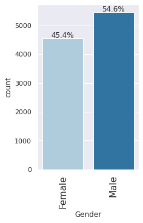

```python
labeled_barplot(Data, "Gender")
```

- There are 54.6% in this dataset in comparison to females.

### Geography

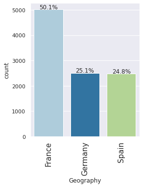

```python
labeled_barplot(Data, "Geography")
```

- 50.1% of customers live in France
- Almost equal number of customers live in Germany and Spain

### HasCrCard

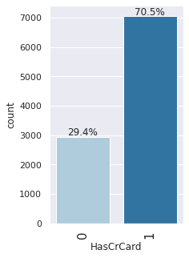

```python
labeled_barplot(Data, "HasCrCard")
```

- 70.5% of the Customers have a credit card

### Tenure

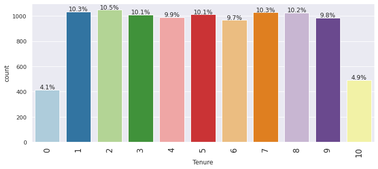

```python
labeled_barplot(Data, "Tenure")
```

- Most of the customers have equally spent between 1 to 9 years
- Few customers have spent 0 and 10 years

### NumOfProducts

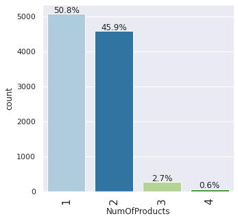

```python
labeled_barplot(Data, "NumOfProducts")
```

- 50.8% of the customers have purchased just one product.
- Very few customers have purchased 3 and 4 products

### isActiveMember

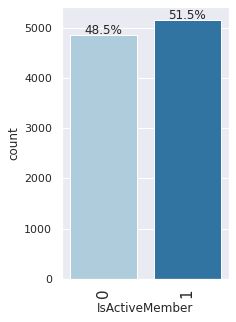

```python
labeled_barplot(Data, "IsActiveMember")
```

- Majority of the customers actively use the bank but it is not significantly different from the percentage of inactive customers

### Target Variable

```python
Data["Exited"].value_counts(1)
```

```
0   0.796
1   0.204
Name: Exited, dtype: float64
```

- This summary shows a problem of an imbalanced dataset
- Only ~20% of the customers left the bank.

## Bivariate Analysis

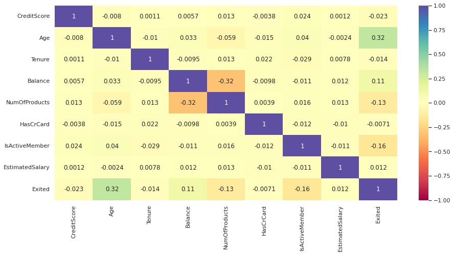

```python
plt.figure(figsize=(15, 7))
sns.heatmap(Data.corr(method = 'spearman'), annot=True, vmin=-1, vmax=1, cmap="Spectral")
plt.show()
```

- There are no high correlations among the different numerical variables
- There might still be correlations among the variables that might not be linear

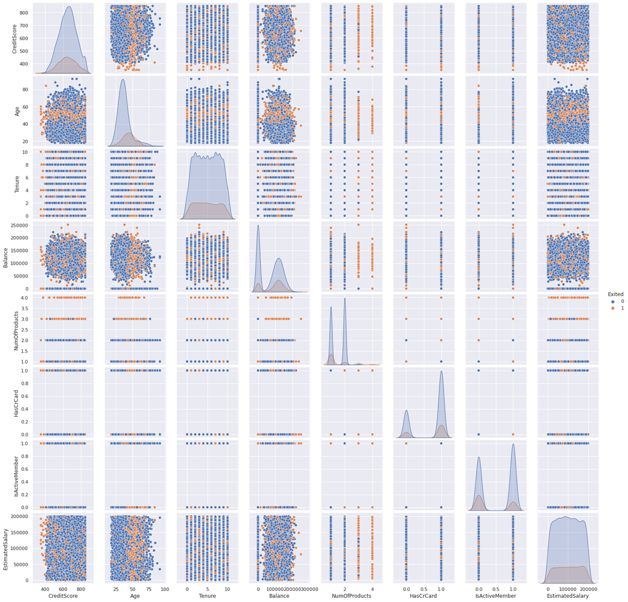

```python
sns.pairplot(data=Data, hue="Exited")
plt.show()
```

- Age seems to a good predictor as most of the customers that left the bank are are within 50 years

```python
### Function to plot distributions


def distribution_plot_wrt_target(data, predictor, target):

    fig, axs = plt.subplots(2, 2, figsize=(12, 10))

    target_uniq = data[target].unique()

    axs[0, 0].set_title("Distribution of target for target=" + str(target_uniq[0]))
    sns.histplot(
        data=data[data[target] == target_uniq[0]],
        x=predictor,
        kde=True,
        ax=axs[0, 0],
        color="teal",
    )

    axs[0, 1].set_title("Distribution of target for target=" + str(target_uniq[1]))
    sns.histplot(
        data=data[data[target] == target_uniq[1]],
        x=predictor,
        kde=True,
        ax=axs[0, 1],
        color="orange",
    )

    axs[1, 0].set_title("Boxplot w.r.t target")
    sns.boxplot(data=data, x=target, y=predictor, ax=axs[1, 0], palette="gist_rainbow")

    axs[1, 1].set_title("Boxplot (without outliers) w.r.t target")
    sns.boxplot(
        data=data,
        x=target,
        y=predictor,
        ax=axs[1, 1],
        showfliers=False,
        palette="gist_rainbow",
    )

    plt.tight_layout()
    plt.show()
```

### CreditScore vs Exited

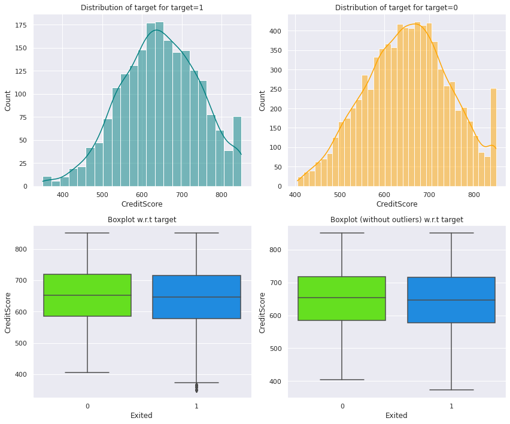

```python
distribution_plot_wrt_target(Data, "CreditScore", "Exited")
```

- From the above plot, we observe that there is no signiificant difference between the Credit scores for Present and Churned customers.
- Cedit score will not be a good predictor

### Age vs Exited

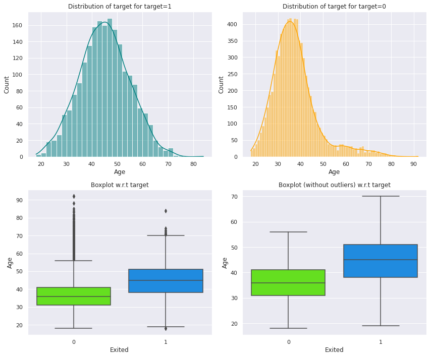

```python
distribution_plot_wrt_target(Data, "Age", "Exited")
```

- From the above plot, we observe that the most of the churned customers are within 50 years of age
- This age is much lower for the loyal customers

```python
# function to plot stacked bar chart


def stacked_barplot(data, predictor, target):
    """
    Print the category counts and plot a stacked bar chart

    data: dataframe
    predictor: independent variable
    target: target variable
    """
    count = data[predictor].nunique()
    sorter = data[target].value_counts().index[-1]
    tab1 = pd.crosstab(data[predictor], data[target], margins=True).sort_values(
        by=sorter, ascending=False
    )
    print(tab1)
    print("-" * 120)
    tab = pd.crosstab(data[predictor], data[target], normalize="index").sort_values(
        by=sorter, ascending=False
    )
    tab.plot(kind="bar", stacked=True, figsize=(count + 1, 5))
    plt.legend(
        loc="lower left",
        frameon=False,
    )
    plt.legend(loc="upper left", bbox_to_anchor=(1, 1))
    plt.show()
```

### Gender vs Exited

```
Exited     0     1    All
Gender
All     7963  2037  10000
Female  3404  1139   4543
Male    4559   898   5457
------------------------------------------------------------------------------------------------------------------------
```

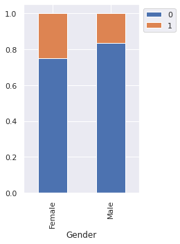

```python
stacked_barplot(Data, "Gender", "Exited")
```

- From the above plot, it is observed that the likelihood of customer churning is higher in females than males

### Geography vs Exited

```
Exited        0     1    All
Geography
All        7963  2037  10000
Germany    1695   814   2509
France     4204   810   5014
Spain      2064   413   2477
------------------------------------------------------------------------------------------------------------------------
```

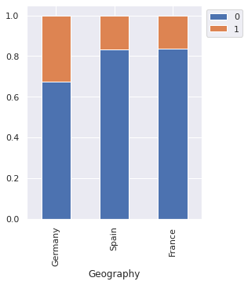

```python
stacked_barplot(Data, "Geography", "Exited")
```

- From the above plot, it was observed that the likelihood of customer churning is significantly higher in customers that live in Germany compared to other countries

# EDA Summary

**Bivariate**

**General**

- There are 2,932 unique values for the Surname. Also, the surname does not add extra information useful for building a predictive model.
- There are no missing values in the dataset
- The dataset contained redundant features that have been dropped, as they will not be useful during the training of the data
- Each value of the columns 'RowNumber' and 'CustomerId' are unique identifiers for a customer.

# Data Pre-processing

### Sparation into Independent and Dependent Columns

```python
## Separating Independent and Dependent Columns
X = Data.drop(['Exited'],axis=1)
Y = Data[['Exited']]
```

### Encoding of Categorical Columns

```python
print("Shape before creating the dummy variables")
print(X.shape)
print("-" * 30)

X = pd.get_dummies(X, drop_first=True)

print("Shape after creating the dummy variables")
print(X.shape)
```

```
Shape before creating the dummy variables
(10000, 10)
------------------------------
Shape after creating the dummy variables
(10000, 11)
```

### Splitting into Train and Test dataset and Rescaling

```python
# Splitting the dataset into the Training and Testing set.

X_train, X_test, y_train, y_test = train_test_split(X,Y, test_size = 0.2, random_state = 1,stratify = Y)
```

```python
print("Percentage of classes in training set:")
print(y_train.value_counts(normalize=True))
print("Percentage of classes in test set:")
print(y_test.value_counts(normalize=True))
```

```
Percentage of classes in training set:
Exited
0        0.796
1        0.204
dtype: float64
Percentage of classes in test set:
Exited
0        0.796
1        0.203
dtype: float64
```

```python
# Resacaling the Data

from sklearn.preprocessing import StandardScaler
scaler = StandardScaler()
X_train = scaler.fit_transform(X_train)
X_test = scaler.transform(X_test)
```

# Model building

#### **A model can make wrong predictions in the following ways:**

- Predicting a customer left the bank, when he/she did not leave.
- Predicting an employee will not leave the bank, when he/she left.

#### Which case is more important?

- Predicting a customer will not attrit but does i.e. losing on a potential customer which comes at a great loss for the bank.

#### How to reduce this loss i.e need to reduce False Negatives?

- Company wants Recall to be maximized, greater the Recall lesser the chances of false negatives.

## Model 1

- Optimizer: SGD
- Epoch: 50
- Layers: 4

```python
backend.clear_session()
#Fixing the seed for random number generators so that we can ensure we receive the same output everytime
np.random.seed(1)
import random
random.seed(1)
tf.random.set_seed(1)
```

```python
# Initializing the ANN
model = Sequential()
model.add(Dense(activation = 'relu', input_dim = 11, units=128))
model.add(Dense(64, activation='relu'))
model.add(Dense(32, activation='relu'))
model.add(Dense(1, activation = 'sigmoid'))
```

```python
# Create optimizer with default learning rate
# Compile the model
model.compile(optimizer='SGD', loss='binary_crossentropy', metrics=[tf.keras.metrics.Recall()])
```

```python
model.summary()
```

```
Model: "sequential"
_________________________________________________________________
 Layer (type)                Output Shape              Param #
=================================================================
 dense (Dense)               (None, 128)               1536

 dense_1 (Dense)             (None, 64)                8256

 dense_2 (Dense)             (None, 32)                2080

 dense_3 (Dense)             (None, 1)                 33

=================================================================
Total params: 11,905
Trainable params: 11,905
Non-trainable params: 0
_________________________________________________________________
```

```python
history=model.fit(X_train, y_train,
          validation_split=0.2,
          epochs=50,
          batch_size=32,verbose=1)
```

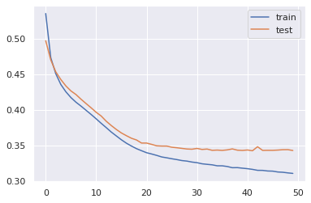

```python
# Capturing learning history per epoch
hist  = pd.DataFrame(history.history)
hist['epoch'] = history.epoch

# Plotting accuracy at different epochs
plt.plot(hist['loss'])
plt.plot(hist['val_loss'])
plt.legend(("train", "test") , loc = 0)

#Printing results
results = model.evaluate(X_test, y_test)
```

- Here the model seems to be a bit overfitted, as the distance between the train curve and test curve started diverging.

```
Best Threshold=0.192005, G-Mean=0.773
```

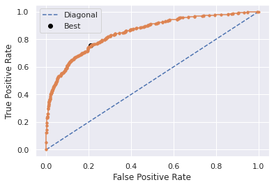

```python
from sklearn.metrics import roc_curve

from matplotlib import pyplot


# predict probabilities
yhat1 = model.predict(X_test)
# keep probabilities for the positive outcome only
yhat1 = yhat1[:, 0]
# calculate roc curves
fpr, tpr, thresholds1 = roc_curve(y_test, yhat1)
# calculate the g-mean for each threshold
gmeans1 = np.sqrt(tpr * (1-fpr))
# locate the index of the largest g-mean
ix = np.argmax(gmeans1)
print('Best Threshold=%f, G-Mean=%.3f' % (thresholds1[ix], gmeans1[ix]))
# plot the roc curve for the model
pyplot.plot([0,1], [0,1], linestyle='--', label='Diagonal')
pyplot.plot(fpr, tpr, marker='.')
pyplot.scatter(fpr[ix], tpr[ix], marker='o', color='black', label='Best')
# axis labels
pyplot.xlabel('False Positive Rate')
pyplot.ylabel('True Positive Rate')
pyplot.legend()
# show the plot
pyplot.show()
```

```python
def confusion_matrix_sklearn(model, predictors, target, threshold = thresholds1[ix]):
    """
    To plot the confusion_matrix with percentages

    model: classifier
    predictors: independent variables
    target: dependent variable
    """
    y_pred = model.predict(predictors)
    y_pred = (y_pred > threshold) + 0
    cm = confusion_matrix(target, y_pred)
    labels = np.asarray(
        [
            ["{0:0.0f}".format(item) + "\n{0:.2%}".format(item / cm.flatten().sum())]
            for item in cm.flatten()
        ]
    ).reshape(2, 2)

    plt.figure(figsize=(6, 4))
    sns.heatmap(cm, annot=labels, fmt="")
    plt.ylabel("True label")
    plt.xlabel("Predicted label")
```

```python
# defining a function to compute different metrics to check performance of a classification model built using sklearn
def model_performance_classification_sklearn(model, predictors, target, threshold = thresholds1[ix]):
    """
    Function to compute different metrics to check classification model performance

    model: classifier
    predictors: independent variables
    target: dependent variable
    """

    # predicting using the independent variables
    pred = model.predict(predictors)
    pred = (pred > threshold) + 0

    acc = accuracy_score(target, pred)  # to compute Accuracy
    recall = recall_score(target, pred)  # to compute Recall
    precision = precision_score(target, pred)  # to compute Precision
    f1 = f1_score(target, pred)  # to compute F1-score

    # creating a dataframe of metrics
    df_perf = pd.DataFrame(
        {
            "Accuracy": acc,
            "Recall": recall,
            "Precision": precision,
            "F1": f1,
        },
        index=[0],
    )

    return df_perf
```

```python
# Calculating different metrics on train set
ANN_train_1 = model_performance_classification_sklearn(model, X_train, y_train)
print("Training performance:")
ANN_train_1
```

```
Training performance:
```

|  | Accuracy | Recall | Precision | F1 |
| --- | --- | --- | --- | --- |
| 0 | 0.799 | 0.796 | 0.505 | 0.618 |

```python
# Calculating different metrics on test set
ANN_test_1 = model_performance_classification_sklearn(model, X_test, y_test)
print("Testing performance:")
ANN_test_1
```

```
Testing performance:
```

|  | Accuracy | Recall | Precision | F1 |
| --- | --- | --- | --- | --- |
| 0 | 0.782 | 0.754 | 0.477 | 0.585 |

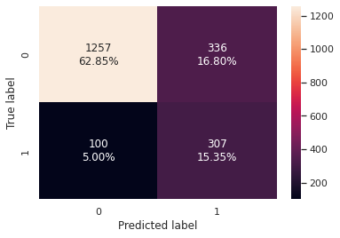

```python
# creating confusion matrix
confusion_matrix_sklearn(model, X_test, y_test)
```

- The recall score of Train and Test samples are high
- The model is generalizing well because the recall of the test and train data are close

# Model Performance Improvement

## Model 2

- Optimizer: Adam
- Epoch: 50
- Layers: 4
- Learning Rate: 0.001

```python
backend.clear_session()
#Fixing the seed for random number generators so that we can ensure we receive the same output everytime
np.random.seed(1)
import random
random.seed(1)
tf.random.set_seed(1)
```

```python
# Initializing the ANN
model1 = Sequential()
model1.add(Dense(activation = 'relu', kernel_initializer='he_uniform', input_dim = 11, units=128))
model1.add(Dense(64, kernel_initializer='he_uniform', activation='relu'))
model1.add(Dense(32, kernel_initializer='he_uniform', activation='relu'))
model1.add(Dense(1, activation = 'sigmoid'))
```

```python
# Create optimizer with default learning rate
#Compiling the ANN with Adam optimizer and binary cross entropy loss function
optimizer = tf.keras.optimizers.Adam(0.001)
model1.compile(optimizer = optimizer, loss = 'binary_crossentropy', metrics = [tf.keras.metrics.Recall()])
```

```python
model1.summary()
```

```
Model: "sequential"
_________________________________________________________________
 Layer (type)                Output Shape              Param #
=================================================================
 dense (Dense)               (None, 128)               1536

 dense_1 (Dense)             (None, 64)                8256

 dense_2 (Dense)             (None, 32)                2080

 dense_3 (Dense)             (None, 1)                 33

=================================================================
Total params: 11,905
Trainable params: 11,905
Non-trainable params: 0
_________________________________________________________________
```

```python
history=model1.fit(X_train, y_train,
          validation_split=0.2,
          epochs=50,
          batch_size=32,verbose=1)
```

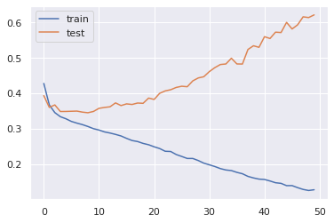

```python
# Capturing learning history per epoch
hist  = pd.DataFrame(history.history)
hist['epoch'] = history.epoch

# Plotting accuracy at different epochs
plt.plot(hist['loss'])
plt.plot(hist['val_loss'])
plt.legend(("train", "test") , loc =0)

#Printing results
results = model1.evaluate(X_test, y_test)
```

- Here the model is highly overfitted, as the distance between the train curve and test curve is very diverged.

```
Best Threshold=0.205823, G-Mean=0.735
```

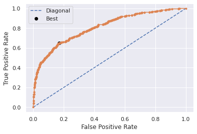

```python
from sklearn.metrics import roc_curve

from matplotlib import pyplot


# predict probabilities
yhat1 = model1.predict(X_test)
# keep probabilities for the positive outcome only
yhat1 = yhat1[:, 0]
# calculate roc curves
fpr, tpr, thresholds1 = roc_curve(y_test, yhat1)
# calculate the g-mean for each threshold
gmeans1 = np.sqrt(tpr * (1-fpr))
# locate the index of the largest g-mean
ix = np.argmax(gmeans1)
print('Best Threshold=%f, G-Mean=%.3f' % (thresholds1[ix], gmeans1[ix]))
# plot the roc curve for the model
pyplot.plot([0,1], [0,1], linestyle='--', label='Diagonal')
pyplot.plot(fpr, tpr, marker='.')
pyplot.scatter(fpr[ix], tpr[ix], marker='o', color='black', label='Best')
# axis labels
pyplot.xlabel('False Positive Rate')
pyplot.ylabel('True Positive Rate')
pyplot.legend()
# show the plot
pyplot.show()
```

```python
# Calculating different metrics on train set
ANN_train_2 = model_performance_classification_sklearn(model1, X_train, y_train)
print("Training performance:")
ANN_train_2
```

```
Training performance:
```

|  | Accuracy | Recall | Precision | F1 |
| --- | --- | --- | --- | --- |
| 0 | 0.902 | 0.904 | 0.702 | 0.790 |

```python
# Calculating different metrics on test set
ANN_test_2 = model_performance_classification_sklearn(model1, X_test, y_test)
print("Testing performance:")
ANN_test_2
```

```
Testing performance:
```

|  | Accuracy | Recall | Precision | F1 |
| --- | --- | --- | --- | --- |
| 0 | 0.787 | 0.651 | 0.483 | 0.554 |

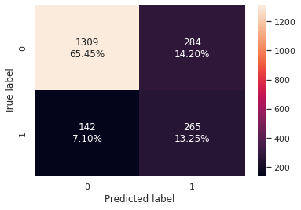

```python
# creating confusion matrix
confusion_matrix_sklearn(model1, X_test, y_test)
```

- The model is highly overfitting on the train data

## Model 3

- Optimizer: Adam
- Epoch: 50
- Layers: 8 (5 Layers + 3 Batch Normalizations)
- Techique: Batch Normalization
- Learning Rate: 0.0001

```python
backend.clear_session()
#Fixing the seed for random number generators so that we can ensure we receive the same output everytime
np.random.seed(1)
import random
random.seed(1)
tf.random.set_seed(1)
```

```python
# Initializing the ANN
model2 = Sequential()
model2.add(Dense(128,activation='relu',input_dim = X_train.shape[1]))
model2.add(BatchNormalization())
model2.add(Dense(64,activation='relu'))
model2.add(BatchNormalization())
model2.add(Dense(64,activation='relu'))
model2.add(BatchNormalization())
model2.add(Dense(32,activation='relu'))
model2.add(Dense(1, activation = 'sigmoid'))
```

```python
# Create optimizer with default learning rate
#Compiling the ANN with Adam optimizer and binary cross entropy loss function
optimizer = tf.keras.optimizers.Adam(0.0001)
model2.compile(optimizer = optimizer, loss = 'binary_crossentropy', metrics = [tf.keras.metrics.Recall()])
```

```python
model2.summary()
```

```
Model: "sequential"
_________________________________________________________________
 Layer (type)                Output Shape              Param #
=================================================================
 dense (Dense)               (None, 128)               1536

 batch_normalization (BatchN  (None, 128)              512
 ormalization)

 dense_1 (Dense)             (None, 64)                8256

 batch_normalization_1 (Batc  (None, 64)               256
 hNormalization)

 dense_2 (Dense)             (None, 64)                4160

 batch_normalization_2 (Batc  (None, 64)               256
 hNormalization)

 dense_3 (Dense)             (None, 32)                2080

 dense_4 (Dense)             (None, 1)                 33

=================================================================
Total params: 17,089
Trainable params: 16,577
Non-trainable params: 512
_________________________________________________________________
```

```python
history=model2.fit(X_train, y_train,
          validation_split=0.2,
          epochs=50,
          batch_size=32,verbose=1)
```

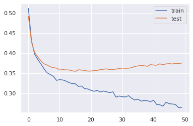

```python
# Capturing learning history per epoch
hist  = pd.DataFrame(history.history)
hist['epoch'] = history.epoch

# Plotting accuracy at different epochs
plt.plot(hist['loss'])
plt.plot(hist['val_loss'])
plt.legend(("train", "test") , loc =0)

#Printing results
results = model2.evaluate(X_test, y_test)
```

- Here the model seems to be highly overfitted, as the distance between the train curve and test curve started increasing.

```
Best Threshold=0.193816, G-Mean=0.762
```

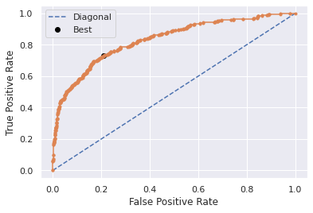

```python
from sklearn.metrics import roc_curve

from matplotlib import pyplot


# predict probabilities
yhat1 = model2.predict(X_test)
# keep probabilities for the positive outcome only
yhat1 = yhat1[:, 0]
# calculate roc curves
fpr, tpr, thresholds1 = roc_curve(y_test, yhat1)
# calculate the g-mean for each threshold
gmeans1 = np.sqrt(tpr * (1-fpr))
# locate the index of the largest g-mean
ix = np.argmax(gmeans1)
print('Best Threshold=%f, G-Mean=%.3f' % (thresholds1[ix], gmeans1[ix]))
# plot the roc curve for the model
pyplot.plot([0,1], [0,1], linestyle='--', label='Diagonal')
pyplot.plot(fpr, tpr, marker='.')
pyplot.scatter(fpr[ix], tpr[ix], marker='o', color='black', label='Best')
# axis labels
pyplot.xlabel('False Positive Rate')
pyplot.ylabel('True Positive Rate')
pyplot.legend()
# show the plot
pyplot.show()
```

```python
# Calculating different metrics on train set
ANN_train_3 = model_performance_classification_sklearn(model2, X_train, y_train)
print("Training performance:")
ANN_train_3
```

```
Training performance:
```

|  | Accuracy | Recall | Precision | F1 |
| --- | --- | --- | --- | --- |
| 0 | 0.846 | 0.869 | 0.582 | 0.697 |

```python
# Calculating different metrics on test set
ANN_test_3 = model_performance_classification_sklearn(model2, X_test, y_test)
print("Testing performance:")
ANN_test_3
```

```
Testing performance:
```

|  | Accuracy | Recall | Precision | F1 |
| --- | --- | --- | --- | --- |
| 0 | 0.778 | 0.732 | 0.472 | 0.574 |

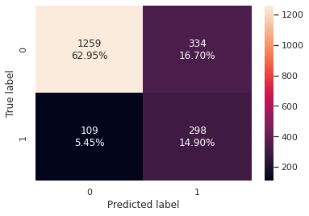

```python
# creating confusion matrix
confusion_matrix_sklearn(model2, X_test, y_test)
```

- There is an improvement from the previous model however, the model is still overfitting